# PS demo2: process a real Perturb-seq data

# Introduction

In this demo, we will process one BeeSTING-seq data from [Morris et al. Science 2023](https://www.science.org/doi/10.1126/science.adh7699). This is a very interesting base editing Perturb-seq dataset, but we will primarily use this dataset as an example to show how to run PS from the very beginning.

# Preprocessing

Load the R libraries

```r
library(Seurat)
library(ggplot2)
library(patchwork)
library(scales)
library(dplyr)
```

If you have not installed scMAGeCK yet, use the following command to install:

```r
if(FALSE){
  library(devtools)
  install_github('weililab/scMAGeCK')
}
```

Once the installation is complete, load scMAGeCK:

```r
library(scMAGeCK)
```

Let’s first read the expression data

```r
exp_mat_GDO=ReadMtx(mtx='counts/GSM7108136_BeeSTINGseq_GDO-A_matrix.mtx.gz',
                    cells='counts/GSM7108136_BeeSTINGseq_GDO-A_barcodes.tsv.gz',
                    features='counts/GSM7108136_BeeSTINGseq_GDO-A_features.tsv.gz')

sobj=CreateSeuratObject(counts=exp_mat_GDO[1:36601,])
sobj[['CRISPR']]=CreateAssayObject(counts=exp_mat_GDO[36602:36939,])
```

The rest is the standard Seurat preprocessing steps. See [Seurat tutorial](https://satijalab.org/seurat/articles/get_started_v5_new) for more details.

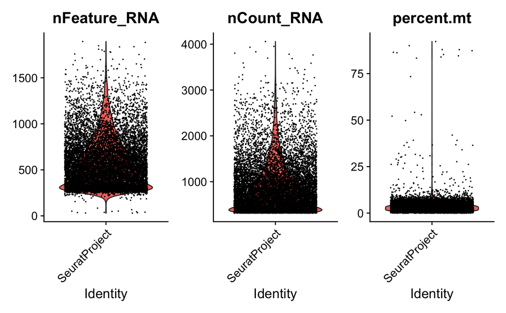

```r
sobj[["percent.mt"]] <- PercentageFeatureSet(sobj, pattern = "^MT-")
VlnPlot(sobj, features = c("nFeature_RNA", "nCount_RNA", "percent.mt"), ncol = 3)
```

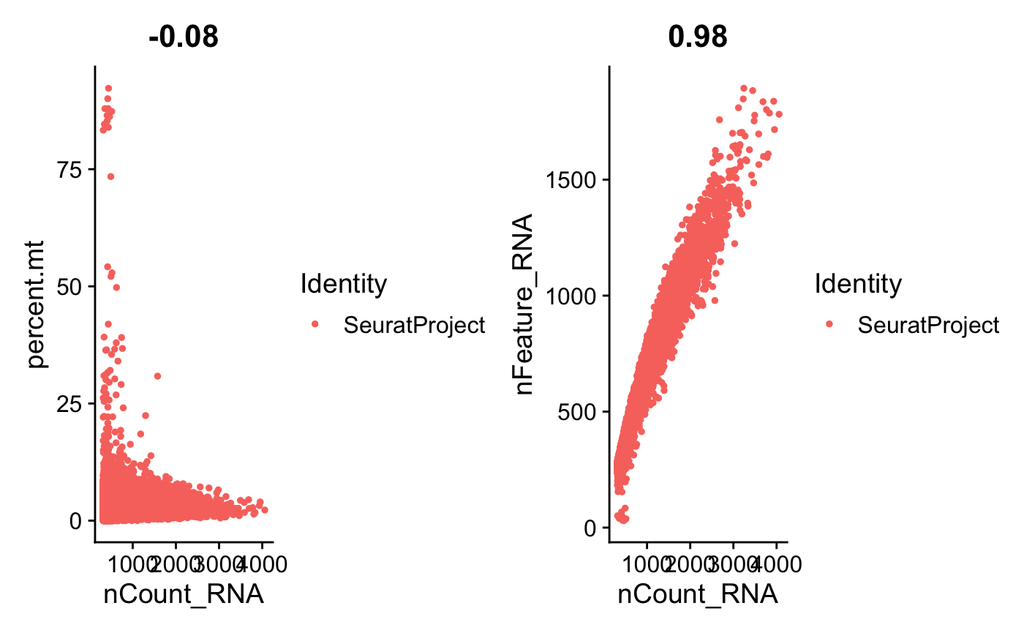

```r
plot1 <- FeatureScatter(sobj, feature1 = "nCount_RNA", feature2 = "percent.mt")
plot2 <- FeatureScatter(sobj, feature1 = "nCount_RNA", feature2 = "nFeature_RNA")
plot1 + plot2
```

```r
# sobj <- subset(sobj, subset = nFeature_RNA > 200 & nFeature_RNA < 4500 & percent.mt < 10)

sobj <- NormalizeData(object = sobj) %>% FindVariableFeatures() %>% ScaleData()
sobj <- RunPCA(object = sobj)
```

```
PC_ 1
Positive:  TXNIP, KLF10, DDIT3, FTL, TMEM70, SQSTM1, SLC3A2, NEU1, MALAT1, PPP1R15A
       BHLHE40, ASAH1, G0S2, RRAGC, ATP6V0D1, SLC25A36, ZNF292, ATP6V0E1, HBP1, AL139260.1
       HIST1H4H, CHD2, ICAM1, FOXN2, OPTN, KLHL24, ARID4B, UPP1, SAT2, UBE2B
Negative:  RPS21, RPLP2, RPL28, HBZ, RPS23, RPL32, GAPDH, RPS4X, PTMA, RPL12
       RPL34, RPL41, RPS12, NME2, H3F3A, EEF1B2, HBG1, MT-CO3, MT-CO2, RPL30
       HSPA8, RPL10, RPLP1, RPL39, H2AFZ, HMGB1, MT-ATP6, HBG2, MT-CYB, HIST1H4C
PC_ 2
Positive:  HBZ, MT-CO2, HBG2, MT-CO3, MT-CO1, MT-ATP6, HBG1, MT-CYB, MT-ATP8, HBE1
       MTRNR2L8, MT-ND5, RPLP2, MT-ND6, FOS, MT-ND4, RPL32, RPL41, RPL28, RPL10
       MT-ND3, MT-ND2, RPS23, RPS12, EGR1, PKLR, RPL34, RPL12, H3F3A, TUBB1
Negative:  CDK1, NEU1, ARL6IP1, TPX2, KPNA2, HMMR, CDCA8, DDIT3, CDCA2, AURKA
       ASPM, SLC3A2, CDC20, TXNIP, PPP1R15A, KLF10, CCNB1, CENPE, TOP2A, NEK2
       KIF20A, SQSTM1, JPT1, DEPDC1, DBF4, NDC80, CCNA2, ACTG1, CKS2, CENPF
PC_ 3
Positive:  TMSB4X, FTL, SH3BGRL3, TMSB10, S100A11, KRT18, TIMP1, RPL10, LGALS1, VIM
       NME2, RPL39, SELENOM, RPS4X, PKM, RPL41, KRT8, RPL34, ARF4, ANXA1
       AL365226.2, RABAC1, RPL30, DBI, ANXA5, HSPA5, RPL28, CAPG, POLD4, S100A6
Negative:  CDCA8, HMMR, ASPM, TOP2A, CDC20, NEK2, CCNB1, CDCA2, CDK1, KIF20A
       CENPE, TPX2, CENPF, AURKA, KIF14, DEPDC1, PTTG1, KIF2C, HJURP, NDC80
       MKI67, NUSAP1, CCNB2, KPNA2, ANLN, PLK1, NCAPD2, CDKN3, KIF4A, CCNA2
PC_ 4
Positive:  HBG2, HBG1, FTL, ALAS2, RPLP1, RPS12, AC079801.1, HBZ, CA1, GYPB
       SLC25A37, HMBS, HBE1, RPL28, RPL39, RPL10, RPL32, RPS23, RPL30, RPL12
       RPS4X, GYPC, RPL41, H2AFZ, SLC3A2, SNHG29, AHSP, TMEM70, AL365226.2, RPLP2
Negative:  MT-CO1, MT-ND6, MTRNR2L8, MT-ND5, MALAT1, MT-CYB, MT-ND2, MT-ATP6, MT-CO2, MT-ATP8
       HIST1H1E, MT-CO3, MTRNR2L12, MT-ND4, AHNAK, MACF1, HIST1H2AH, AC011603.2, PKM, MT-ND3
       HNRNPA3, ZNF664, SRRM2, SPTBN1, NEAT1, MSN, SLC2A3, HSP90B1, IQGAP1, VCL
PC_ 5
Positive:  HBG2, ALAS2, HBG1, SLC25A37, HBE1, HMBS, HBZ, AC079466.1, HEMGN, GYPB
       MALAT1, CA1, HMGCS1, AC016629.2, HIST1H1C, AC079801.1, MT-CO1, TFRC, HIST1H1E, SLC4A1
       GYPC, MSMO1, INSIG1, NFE2, CYP51A1, SCD, SQLE, LBH, SPTA1, NEAT1
Negative:  LGALS1, S100A11, PKM, TMSB10, TMSB4X, VIM, PTTG1, CDC20, UPP1, KRT8
       ARL6IP1, KPNA2, CCNB1, SH3BGRL3, CKS2, IFITM1, MIF, PLK1, TIMP1, LDHA
       ANXA1, PLP2, JPT1, HMMR, NQO1, H2AFZ, APOC1, ACTG1, S100A13, CENPE
```

```r
sobj <- RunUMAP(object = sobj, dims = 1:10)
sobj <- FindNeighbors(sobj, dims = 1:10)
sobj <- FindClusters(sobj, resolution = 0.5)
```

```
Modularity Optimizer version 1.3.0 by Ludo Waltman and Nees Jan van Eck

Number of nodes: 11765
Number of edges: 343093

Running Louvain algorithm...
```

```
Maximum modularity in 10 random starts: 0.8238
Number of communities: 8
Elapsed time: 1 seconds
```

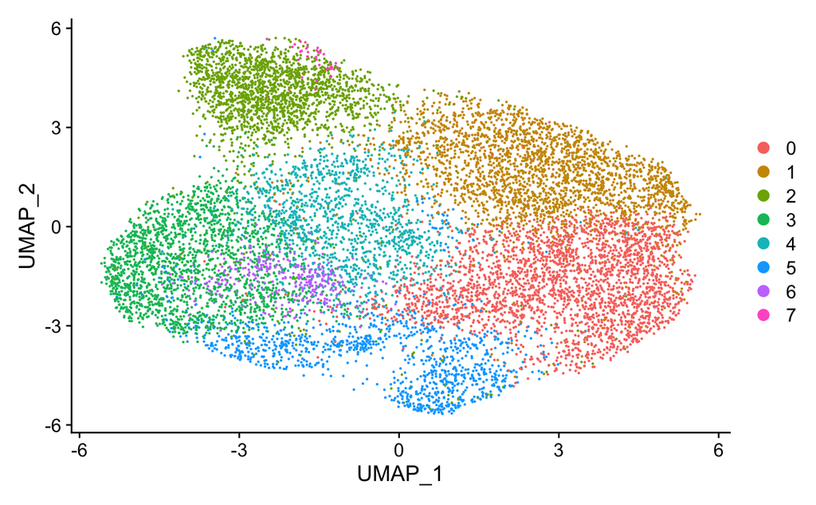

```r
DimPlot(sobj, reduction = "umap")
```

# Calculate PS scores

Now we start with PS calculation.

## Step 1: prepare barcode files

First, we need to extract the barcode file which will be necessary for running PS:

```r
bc_frame=guidematrix_to_triplet(sobj[['CRISPR']]@counts,sobj)
```

```
as(<dgCMatrix>, "dgTMatrix") is deprecated since Matrix 1.5-0; do as(., "TsparseMatrix") instead
```

```r
bc_frame[,'sgrna']=bc_frame[,'barcode']
bc_frame[,'gene']=sub('-[0-9]+$','',bc_frame[,'barcode'])

# filter barcode file to only keep guides with >1 read counts

bc_frame <- bc_frame[bc_frame$read_count>1,]
```

## Step 2: pre-process guide expression matrix

```r
DefaultAssay(sobj)='CRISPR'

sobj <- pre_processRDS(bc_frame, sobj)
```

```
Total barcode records: 72438
Assigning cell identity with highest gRNA expressions (you can change it later by rerunning assign_cell_identity function
Creating sgRNA expression matrix
Normalizing across features
```

[output not shown]

[output cut: 49 more lines]

[output not shown]

```
Creating sgRNA expression matrix at the guide level
Warning: Keys should be one or more alphanumeric characters followed by an underscore, setting key from sgrna_guides_ to sgrnaguides_Normalizing across features
```

[output not shown]

[output cut: 282 more lines]

[output not shown]

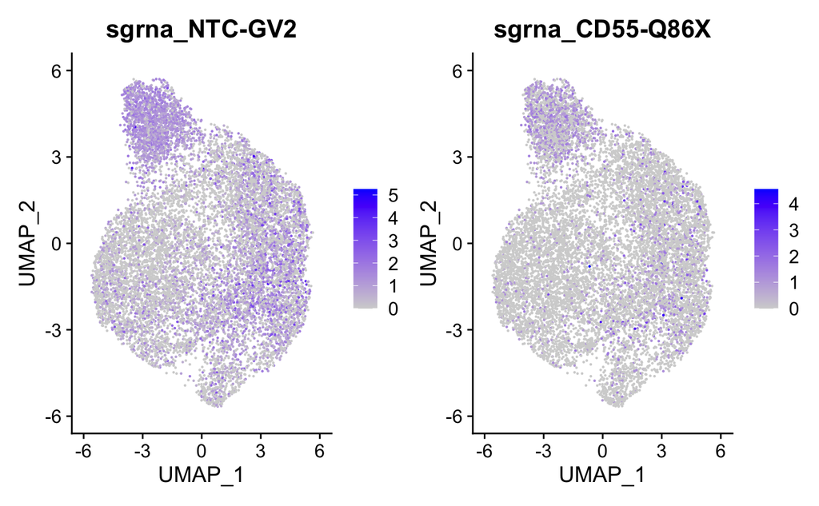

```r
FeaturePlot(sobj,features=c('NTC-GV2','CD55-Q86X'))
```

## Step 3: run PS method

Use *scmageck_eff_estimate* function to calculate PS score. For more information, use *?scmageck_eff_estimate*

```r
DefaultAssay(sobj)<-'RNA'

# test CD55

eff_object <- scmageck_eff_estimate(sobj, bc_frame, perturb_gene=c('SNP-36'),
                                    non_target_ctrl = 'NTC-GV2',subset_rds = T, lambda = 0, target_gene_max = 100)
```

```
Target gene list not provided. Search for target gene list..
Search for SNP-36 target genes..
```

[output not shown]

[output cut: 40 more lines]

[output not shown]

```
DE analysis identified  1221 DE genes that will be used for target genes.
Select 100 genes
Using scmageck_lr for initial beta score estimation...
run_signature: FALSE
Total barcode records: 10162
Neg Ctrl guide: NTC-GV2
5569 ...
5569 ...
Index matrix dimension: 5569 , 2
Filter genes whose expression is greater than 0 in raw read count in less than 0.01 single-cell populations.
Selected genes: 100
Selected cells: 5569
Permutation: 100 / 100 ...
Performing quadratic optimizaiton...
Warning: Invalid name supplied, making object name syntactically valid. New object name is SNP.36_eff; see ?make.names for more details on syntax validity
```

```r
eff_estimat=eff_object$eff_matrix
rds_subset=eff_object$rds
```

Now you can visualize the PS scores

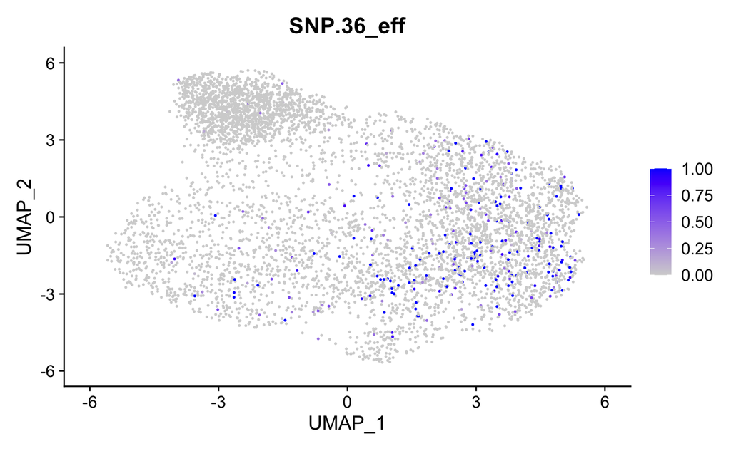

```r
FeaturePlot(rds_subset,features='SNP.36_eff')
```

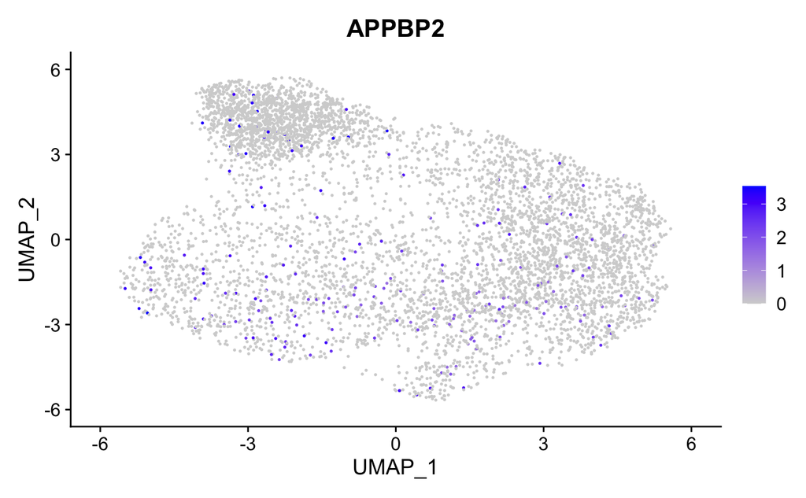

```r
FeaturePlot(rds_subset,features = 'APPBP2')
```

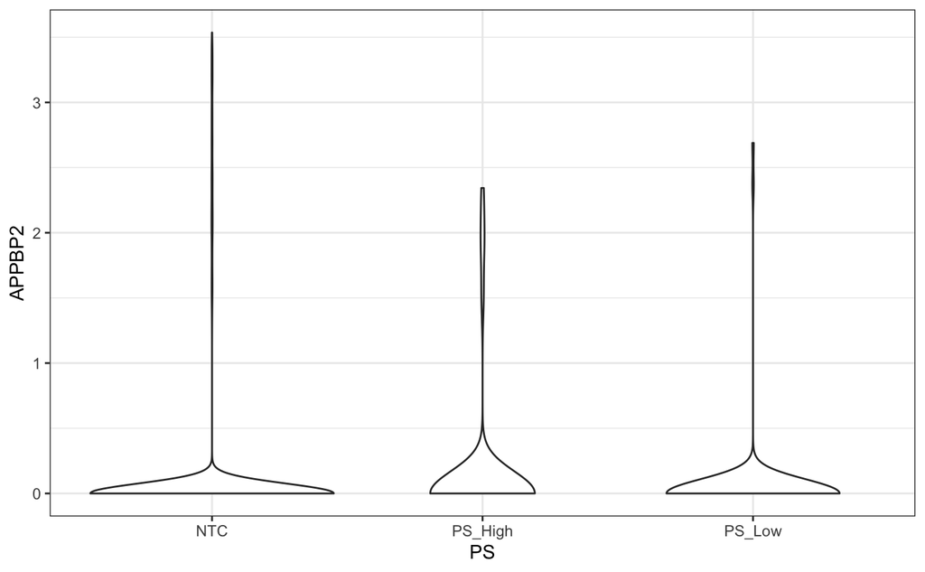

```r
data_f=FetchData(rds_subset,vars = c('sgrna','gene','APPBP2','SNP.36_eff'))

library(ggplot2)

data_f$PS=ifelse(data_f$gene=='NTC-GV2','NTC',ifelse(data_f$SNP.36_eff > 0.5, 'PS_High','PS_Low'))
#data_f$PS=ifelse(data_f$CD55.Q86X_eff > 0.5, 'PS_High','PS_Low')

p<-ggplot(data_f,aes(x=PS,y=APPBP2)) +
  geom_violin() +
  theme_bw()

print(p)
```

```r
NA
NA
```

An ECDF plot can be shown for different groups:

```r
plot(ecdf(data_f$APPBP2[data_f$gene=='NTC-GV2']),ylim=c(0.9,1),xlab='APPBP2 expression',ylab='Fraction')
plot(ecdf(data_f$APPBP2[data_f$SNP.36_eff<0.2]),add=T,col='blue')
```

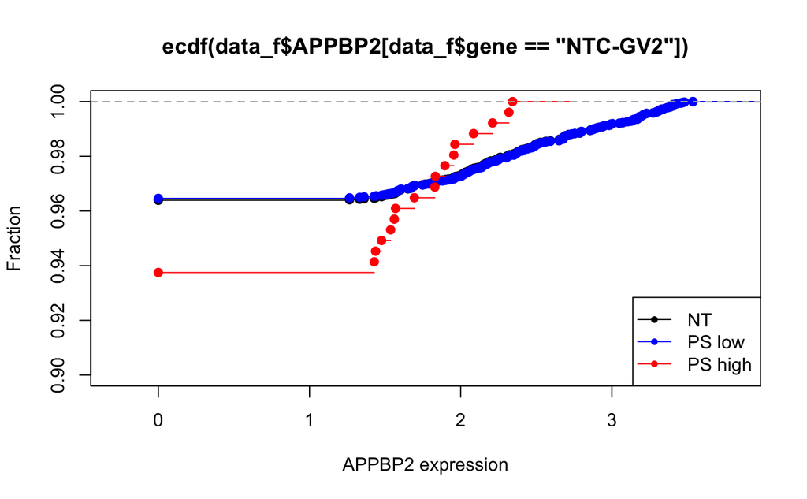

```r
plot(ecdf(data_f$APPBP2[data_f$SNP.36_eff>0.2]),add=T,col='red')

legend('bottomright',c('NT','PS low','PS high'),col=c('black','blue','red'),lwd=1,pch=20)
```